# UTS MPDW Rheyhan Fahry

$H_0$ : Sisaan saling bebas

$H_1$ : Sisaan tidak tidak saling bebas

Berdasarkan uji Ljung-Box tersebut, didapat *p-value* sebesar 0.9845 yang lebih besar dari taraf nyata 5% sehingga tak tolak $H_0$ dan menandakan bahwa sisaan saling bebas. Hal ini berbeda dengan eksplorasi.

```r
#3) Sisaan homogen
Box.test((sisaan.da)^2, type = "Ljung")  #tak tolak H0 > sisaan homogen
```

```
##
##  Box-Ljung test
##
## data:  (sisaan.da)^2
## X-squared = 0.015618, df = 1, p-value = 0.9005
```

Hipotesis yang digunakan untuk uji kehomogenan ragam adalah sebagai berikut.

$H_0$ : Ragam sisaan homogen

$H_1$ : Ragam sisaan tidak homogen

```r
#4) Nilai tengah sisaan sama dengan nol
t.test(sisaan.da, mu = 0, conf.level = 0.95)  #tak tolak h0 > nilai tengah sisaan sama dengan 0
```

```
##
##  One Sample t-test
##
## data:  sisaan.da
## t = 0.28845, df = 132, p-value = 0.7735
## alternative hypothesis: true mean is not equal to 0
## 95 percent confidence interval:
##  -12.99787  17.43572
## sample estimates:
## mean of x
##  2.218923
```

Terakhir, dengan uji-t, akan dicek apakah nilai tengah sisaan sama dengan nol. Hipotesis yang diujikan sebagai berikut.

$H_0$ : nilai tengah sisaan sama dengan 0

$H_1$ : nilai tengah sisaan tidak sama dengan 0

##Peramalan

```r
#---FORECAST---#
ramalan.da <- forecast::forecast(model2, h = h)
ramalan.da
```

```
##     Point Forecast     Lo 80    Hi 80     Lo 95    Hi 95
## 135      -13.85518 -128.8880 101.1776 -189.7827 162.0723
## 136      -12.88733 -130.0271 104.2524 -192.0371 166.2625
## 137      -12.88733 -130.0271 104.2524 -192.0371 166.2625
## 138      -12.88733 -130.0271 104.2524 -192.0371 166.2625
## 139      -12.88733 -130.0271 104.2524 -192.0371 166.2625
## 140      -12.88733 -130.0271 104.2524 -192.0371 166.2625
## 141      -12.88733 -130.0271 104.2524 -192.0371 166.2625
## 142      -12.88733 -130.0271 104.2524 -192.0371 166.2625
## 143      -12.88733 -130.0271 104.2524 -192.0371 166.2625
## 144      -12.88733 -130.0271 104.2524 -192.0371 166.2625
## 145      -12.88733 -130.0271 104.2524 -192.0371 166.2625
## 146      -12.88733 -130.0271 104.2524 -192.0371 166.2625
## 147      -12.88733 -130.0271 104.2524 -192.0371 166.2625
## 148      -12.88733 -130.0271 104.2524 -192.0371 166.2625
## 149      -12.88733 -130.0271 104.2524 -192.0371 166.2625
```

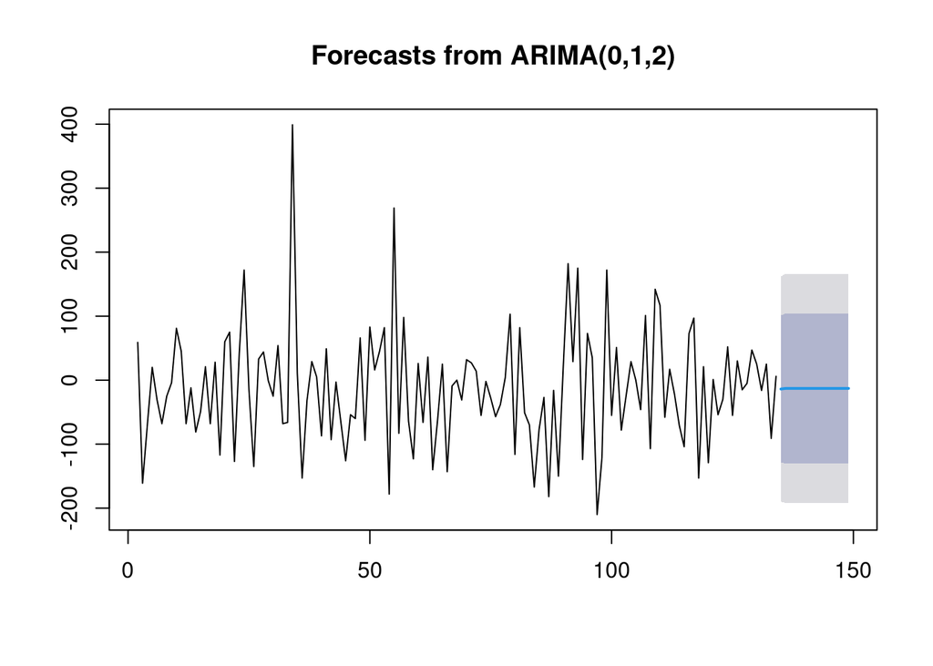

```r
data.ramalan.da <- ramalan.da$mean
plot(ramalan.da)
```

Berdasarkan hasil plot ramalan di atas, dapat dilihat bahwa ramalan ARIMA(0,012) cenderung stabil hingga akhir periode. Selanjutnya, dapat dicari nilai akurasi antara hasil ramalan dengan data uji sebagai berikut.

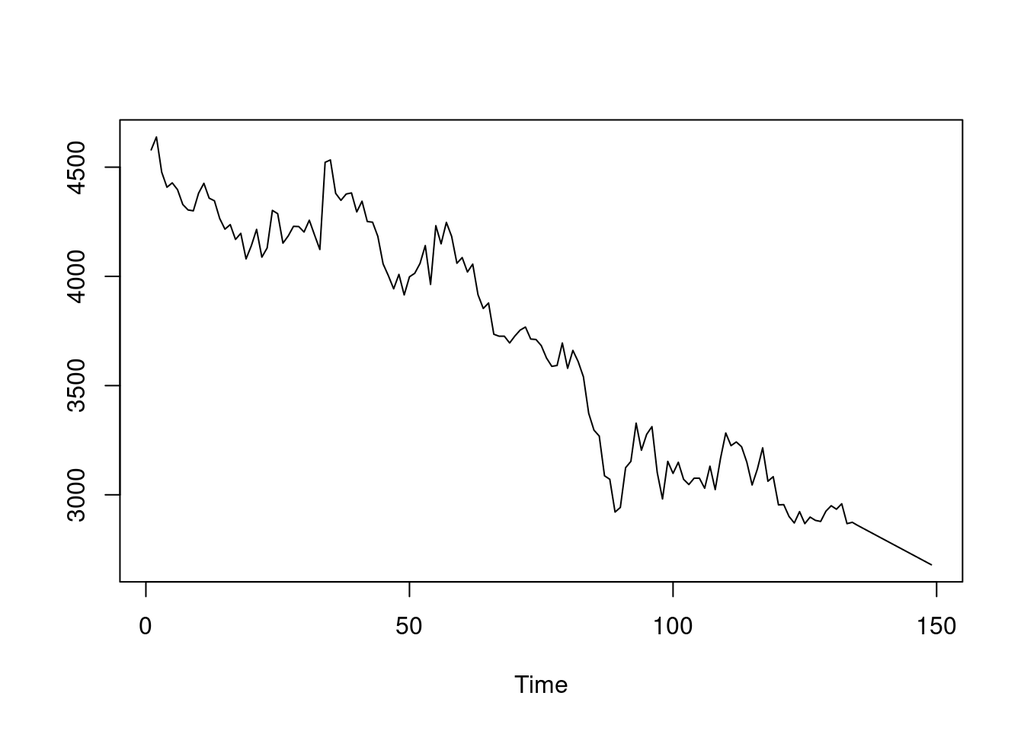

```r
pt_1 <- train.ts[length(train.ts)] #nilai akhir data latih
hasil.forc.Diff <- data.ramalan.da
hasil <- diffinv(hasil.forc.Diff, differences = 1) + pt_1
#has.1 sama hasilnta dengan: cumsum(c(pt_1,hasil.forc.Diff))
ts.plot(train.ts,hasil)
```

```r
perbandingan.da<-matrix(data=c(head(test.ts, n=h), hasil[-1]),
                     nrow = h, ncol = 2)
colnames(perbandingan.da)<-c("Aktual","Hasil Forecast")
perbandingan.da
```

```
##       Aktual Hasil Forecast
##  [1,]   2790       2860.145
##  [2,]   2748       2847.257
##  [3,]   2725       2834.370
##  [4,]   2751       2821.483
##  [5,]   2786       2808.596
##  [6,]   2740       2795.708
##  [7,]   2688       2782.821
##  [8,]   2706       2769.934
##  [9,]   2630       2757.046
## [10,]   2583       2744.159
## [11,]   2582       2731.272
## [12,]   2580       2718.384
## [13,]   2615       2705.497
## [14,]   2550       2692.610
## [15,]   2550       2679.722
```

```r
accuracy(ts(hasil[-1]), head(test.ts, n=h))
```

```
##                 ME     RMSE      MAE      MPE    MAPE      ACF1 Theil's U
## Test set -101.6669 108.7182 101.6669 -3.85276 3.85276 0.5349255  2.806313
```